# Vibración forzada sin amortiguamiento

\begin{equation*} m \ddot{u} + k u = F_{0} \sin \bigl( \bar{\omega} t \bigr) \end{equation*}

Reescribiendo la ecuación

\begin{equation} \ddot{u} + \omega^{2} u = \frac{F_{0}}{m} \sin \bigl( \bar{\omega} t \bigr) \end{equation}

La solución es

\begin{equation*} u = A_{1} \sin \bigl( \omega t \bigr) + A_{2} \cos \bigl( \omega t \bigr) + G \sin \bigl( \bar{\omega} t \bigr) \end{equation*}

Coeficientes

\begin{align*} \gamma &= \frac{\bar{\omega}}{\omega} \\ A_{1} &= \frac{\dot{u}_{0}}{\omega} - \frac{F_{0}}{k} \frac{\gamma}{1 - \gamma^{2}}\\ A_{2} &= u_{0} \\ G &= \frac{F_{0}}{k} \frac{1}{1 - \gamma^{2}} \end{align*}

# Ejemplo en clase

Usando

\begin{equation*} u = A \sin \bigl( \omega t \bigr) + B \cos \bigl( \omega t \bigr) + G \sin \bigl( \bar{\omega} t \bigr) \end{equation*}

```python
import numpy as np
import matplotlib.pyplot as plt

w = 25.0  # Tn
m = w/981.0 # Tn/cm/seg^2
k = 7.0  # Tn/cm
u0 = 0.0  # cm
v0 = 0.0 # cm/seg
beta = 0.07
F0 = 2.0
omega_bar = 18.1

omega = np.power(k/m,1.0/2.0)
gamma = omega_bar/omega
G = (F0/k)*(1.0)/(1.0 - gamma**2)
A = (v0/omega) - (F0/k)*(gamma)/(1.0 - gamma**2)
B = u0

print 'omega =', omega
print 'gamma =',gamma
print 'G =', G
print 'A =', A
print 'B =', B
```

```
omega = 16.5734727803
gamma = 1.09210665984
G = -1.48271301719
A = 1.6192807607
B = 0.0
```

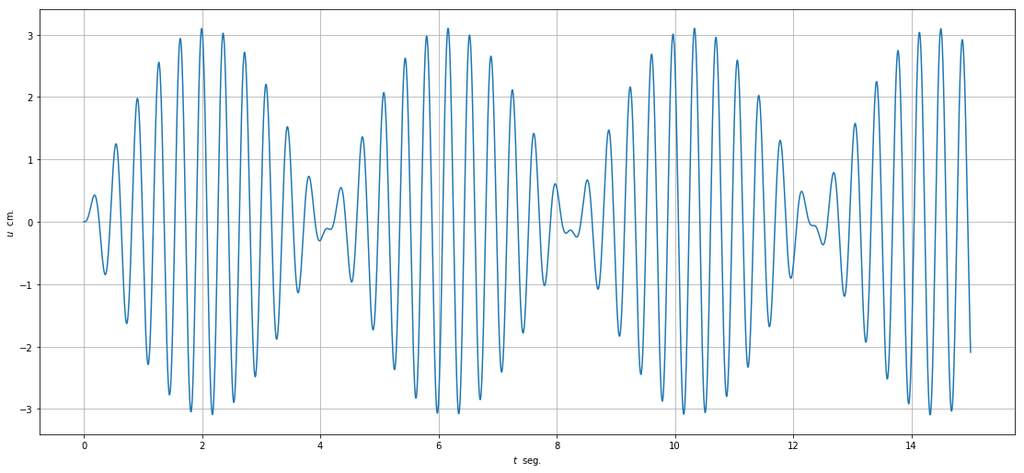

```python
t = np.linspace(0,15,15000)
posicion = A*np.sin(omega*t) + B*np.cos(omega*t) + G*np.sin(omega_bar*t)

plt.figure(figsize=(19,8.5))
plt.plot(t,posicion)
plt.xlabel(r'$t$  seg.')
plt.ylabel(r'$u$  cm.')
plt.grid(True)
plt.show()
```

Cuando $u_{0} = 0$ y $\dot{u}_{0} = 0$

\begin{equation*} u = A_{1} \sin \bigl( \omega t \bigr) + G \sin \bigl( \bar{\omega} t \bigr) \end{equation*}

Coeficientes

\begin{align*} \gamma &= \frac{\bar{\omega}}{\omega} \\ A_{1} &= - \frac{F_{0}}{k} \frac{\gamma}{1 - \gamma^{2}}\\ G &= \frac{F_{0}}{k} \frac{1}{1 - \gamma^{2}} \end{align*}

```python
import numpy as np
import matplotlib.pyplot as plt

w = 25.0  # Tn
m = w/981.0 # Tn/cm/seg^2
k = 7.0  # Tn/cm
beta = 0.07
F0 = 2.0
omega_bar = 18.1

omega = np.power(k/m,1.0/2.0)
gamma = omega_bar/omega
G = (F0/k)*(1.0)/(1.0 - gamma**2)
A = -(F0/k)*(gamma)/(1.0 - gamma**2)

print 'omega =', omega
print 'gamma =',gamma
print 'G =', G
print 'A =', A
```

```
omega = 16.5734727803
gamma = 1.09210665984
G = -1.48271301719
A = 1.6192807607
```

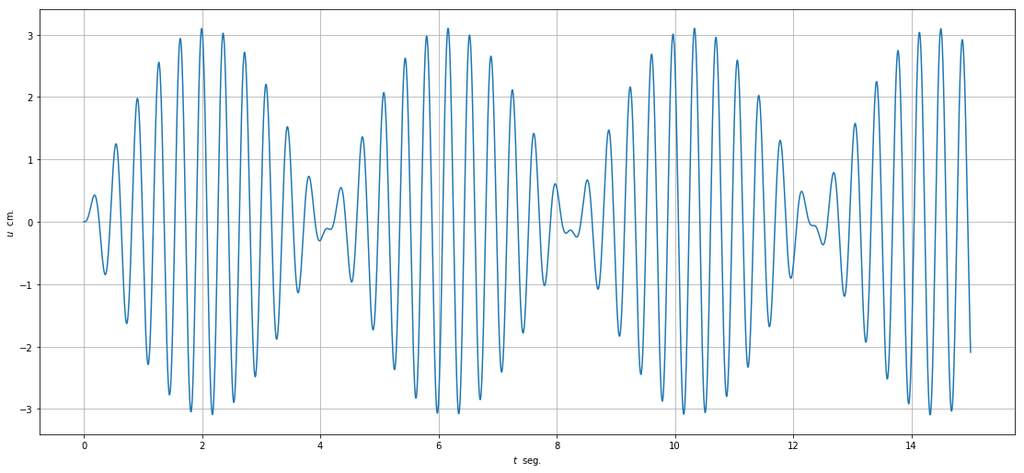

```python
t = np.linspace(0,15,15000)
posicion = A*np.sin(omega*t) + G*np.sin(omega_bar*t)

plt.figure(figsize=(19,8.5))
plt.plot(t,posicion)
plt.xlabel(r'$t$  seg.')
plt.ylabel(r'$u$  cm.')
plt.grid(True)
plt.show()
```

Usando *odeint*

\begin{align*} u^{\prime} &= z \\ z^{\prime} + \omega^{2} u &= \frac{F_{0}}{m} \sin \bigl( \bar{\omega} t \bigr) \end{align*}

sujeto a $u(0) = 0$ y $u^{\prime}(0) = 0$

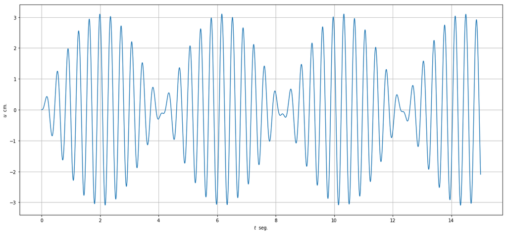

```python
from scipy.integrate import odeint
import numpy as np
import matplotlib.pyplot as plt

def dU_dx(U, x):
    # Here U is a vector such that y=U[0] and z=U[1]. This function should return [z', u']
    m = 25.0/981.0
    k = 7.0
    omega = np.power(k/m,1.0/2.0)
    F0 = 2.0
    omega_bar = 18.1
    return [U[1],-omega**2*U[0] + (F0/m)*np.sin(omega_bar*x)]
U0 = [0.0,0.0]
#U0 = [6.5,32.0]
xs = np.linspace(0, 15, 15000)
Us = odeint(dU_dx, U0, xs)
ys = Us[:,0]

plt.figure(figsize=(19,8.5))
plt.plot(xs, ys)
plt.xlabel(r'$t$  seg.')
plt.ylabel(r'$u$  cm.')
plt.grid(True)
plt.show()
```

Valor máximo aproximado

```python
valor_pico = np.where(posicion >= max(posicion))[0]
print 't pico =', t[valor_pico[0]]
print 'valor pico =', posicion[valor_pico[0]]
```

```
t pico = 6.16141076072
valor pico = 3.1018116753
```

Gráfico interactivo

```python
import plotly.offline as offline
import plotly.graph_objs as go
import numpy as np

offline.init_notebook_mode()

t = np.linspace(0,15,15000)
posicion = A*np.sin(omega*t) + B*np.cos(omega*t) + G*np.sin(omega_bar*t)
trace = go.Scatter(x = t, y = posicion)
data = [trace]

offline.iplot(data)
```

[interactive chart not shown]

# Desplazamientos máximos

Usando la transformada de Hilbert

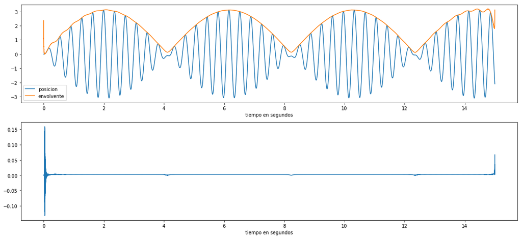

```python
import numpy as np
import matplotlib.pyplot as plt
from scipy.signal import hilbert

t = np.linspace(0,15,15000)
posicion = A*np.sin(omega*t) + B*np.cos(omega*t) + G*np.sin(omega_bar*t)
analytic_signal = hilbert(posicion)
amplitude_envelope = np.abs(analytic_signal)
instantaneous_phase = np.unwrap(np.angle(analytic_signal))
instantaneous_frequency = (np.diff(instantaneous_phase)/(2.0*np.pi))
fig = plt.figure(figsize=(19,8.5))
ax0 = fig.add_subplot(211)
ax0.plot(t, posicion, label='posicion')
ax0.plot(t, amplitude_envelope, label='envolvente')
ax0.set_xlabel("tiempo en segundos")
ax0.legend()
ax1 = fig.add_subplot(212)
ax1.plot(t[1:], instantaneous_frequency)
ax1.set_xlabel("tiempo en segundos")

plt.show()
```

Usando *argrelextrema*

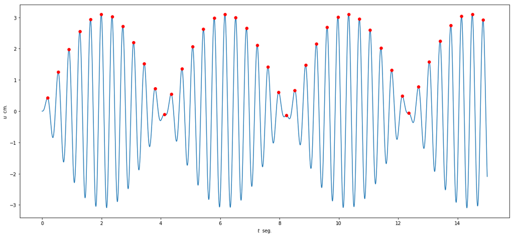

```python
import numpy as np
from scipy.signal import argrelextrema
import matplotlib.pyplot as plt

t = np.linspace(0,15,15000)
posicion = A*np.sin(omega*t) + B*np.cos(omega*t) + G*np.sin(omega_bar*t)

maximo = argrelextrema(posicion, np.greater)[0] #array of indexes of the locals maxima
x = [t[maximo] for i in maximo][0]
y = [posicion[maximo] for i in maximo][0]

plt.figure(figsize=(19,8.5))
plt.plot(t,posicion)
plt.plot(x, y, 'ro')
plt.xlabel(r'$t$  seg.')
plt.ylabel(r'$u$  cm.')
plt.show()
```

Desplazamiento máximo

```python
for i in range(np.size(x)):
    print i, '\t', round(x[i],3), '\t', round(y[i],3)
```

```
0 	0.181 	0.428
1 	0.544 	1.25
2 	0.906 	1.978
3 	1.268 	2.556
4 	1.631 	2.939
5 	1.993 	3.098
6 	2.356 	3.022
7 	2.718 	2.716
8 	3.08 	2.204
9 	3.443 	1.524
10 	3.805 	0.728
11 	4.116 	-0.107
12 	4.349 	0.549
13 	4.711 	1.362
14 	5.074 	2.071
```

[output cut: 28 more lines]

Periodo aproximado

```python
for i in range(np.size(x) - 1):
    print i+1, '\t', x[i+1]-x[i]
```

```
1 	0.363024201613
2 	0.362024134942
3 	0.362024134942
4 	0.363024201613
5 	0.362024134942
6 	0.363024201613
7 	0.362024134942
8 	0.362024134942
9 	0.363024201613
10 	0.362024134942
11 	0.311020734716
12 	0.233015534369
13 	0.362024134942
14 	0.363024201613
15 	0.362024134942
```

[output cut: 27 more lines]

# Resonancia

\begin{equation*} u = - \frac{F_{0}}{k} \frac{\gamma}{1 - \gamma^{2}} \sin \bigl( \omega t \bigr) + \frac{F_{0}}{k} \frac{1}{1 - \gamma^{2}} \sin \bigl( \bar{\omega} t \bigr) \end{equation*}

Se produce cuando $\gamma = 1$

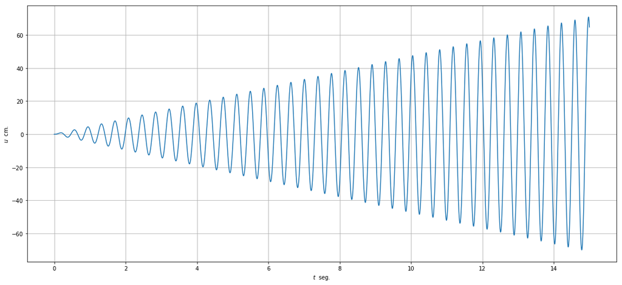

```python
t = np.linspace(0,15,15000)
posicion = (-F0/k)*omega*t*np.cos(omega*t) + (F0/k)*np.sin(omega*t)

plt.figure(figsize=(19,8.5))
plt.plot(t,posicion)
plt.xlabel(r'$t$  seg.')
plt.ylabel(r'$u$  cm.')
plt.grid(True)
plt.show()
```